# The Boss Effect

What 250 Days of Data Tell Patrick About His Most Valuable Asset: His Time

Author

Salman Ahmad Shah Khagga

## One Question Worth Answering

Patrick runs 5 shops and can only be at one place per day. So which shop actually needs him there?

I looked at 250 days of records — cars fixed, which shop, and whether Patrick was present. The charts below show what I found. I kept it simple: what the numbers say, how confident we should be, and what Patrick should probably do next.

## At a Glance — The Boss Effect by Shop

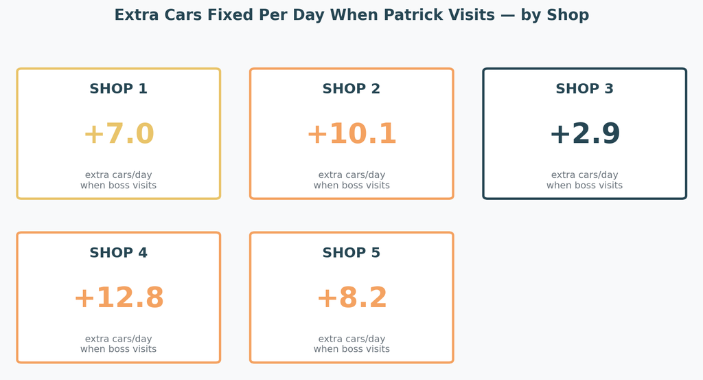

Average extra cars fixed per day when Patrick shows up. Orange = high impact. Gold = decent boost. Teal = little change.

Each number is the average gap between days Patrick showed up and days he did not. Bigger number means his visit made more of a difference at that shop.

## All 250 Days — Every Dot Is One Real Day

Orange dots are days Patrick was there. Teal dots are days he was not. The horizontal lines are the averages. The shaded area behind each line shows how much those averages could reasonably shift given the sample size.

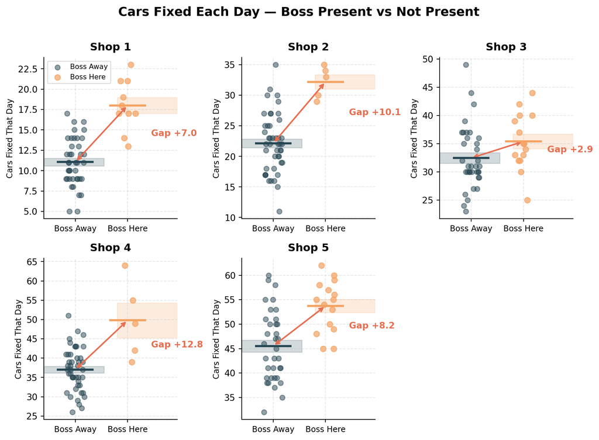

Figure 1: Every observation in the dataset. One dot per shop per day.

Shop 4 has the biggest visible gap — orange dots are clearly higher than teal. Shop 2 shows a similar pattern. Shop 3 is the flattest of all five, meaning Patrick’s presence there barely shifted output. His brother’s crew seems to handle things fine on their own.

## Which Shop Gets the Most Out of a Visit?

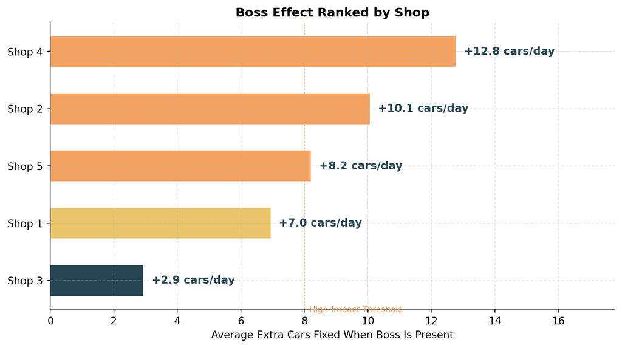

Figure 2: Boss effect ranked. Higher bar means Patrick’s presence moved the needle more at that shop.

|  | Shop | Days Away / Here | Avg Without Patrick | Avg With Patrick | Boss Effect | Realistic Range | Priority |
| --- | --- | --- | --- | --- | --- | --- | --- |
|  | Shop 1 | 40 / 10 | 11.1 | 18.0 | +7.0 | +4.8 to +9.1 | Medium |
|  | Shop 2 | 45 / 5 | 22.1 | 32.2 | +10.1 | +7.4 to +12.7 | High |
|  | Shop 3 | 35 / 15 | 32.5 | 35.4 | +2.9 | -0.2 to +6.1 | Low |
|  | Shop 4 | 45 / 5 | 37.0 | 49.8 | +12.8 | +3.8 to +21.8 | High |
|  | Shop 5 | 35 / 15 | 45.5 | 53.7 | +8.2 | +4.6 to +11.8 | High |

The “Realistic Range” column matters. It shows what the boost could reasonably be — not just the average, but the range you would expect if this played out over more days. Shop 4 has a wide range partly because Patrick only visited 5 times in the whole dataset, so there is less to go on there.

## What Is a Visit Actually Worth in Revenue?

Assuming **$150 per car fixed**:

|  | Shop | Boss Effect | Revenue Per Visit | Revenue if 50 Visits | Priority |
| --- | --- | --- | --- | --- | --- |
|  | Shop 1 | +7.0 | $1,042 | $52,125 | Medium |
|  | Shop 2 | +10.1 | $1,510 | $75,525 | High |
|  | Shop 3 | +2.9 | $441 | $22,050 | Low |
|  | Shop 4 | +12.8 | $1,917 | $95,850 | High |
|  | Shop 5 | +8.2 | $1,233 | $61,650 | High |

A visit to Shop 4 on a typical day adds around **$1,900 in output** compared to Patrick not being there. That is not from hiring anyone new or buying equipment — just from showing up at the right place.

## Three Ways Patrick Could Schedule His Time

This uses 50 total Patrick visit-days per year across all shops and projects what total output looks like under each approach.

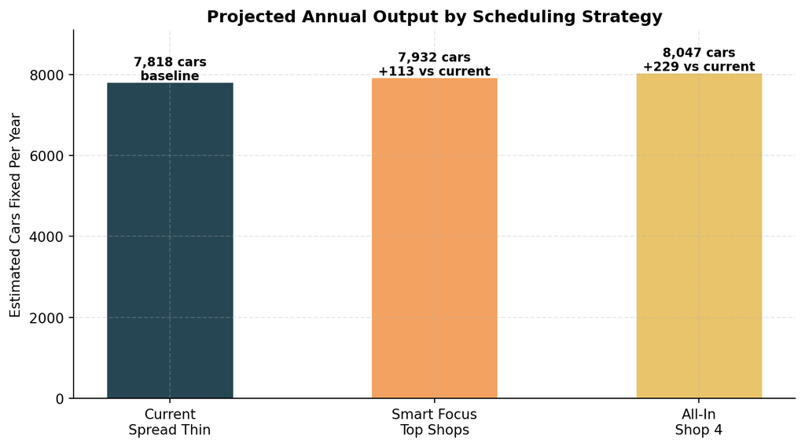

Figure 3: Projected annual output under three scheduling choices. Same number of days — different choices about where to go.

Shifting visits toward the higher-impact shops adds more than **100 extra cars per year** compared to spreading time equally — same number of days, just better choices about where to go.

## How Much Should Patrick Trust These Numbers?

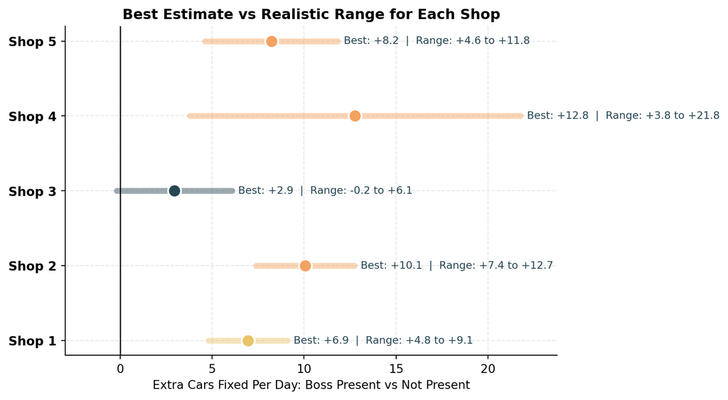

Figure 4: The dot is the best estimate. The thick bar shows the realistic range at 95% confidence.

250 days sounds like a lot but once it is split across 5 shops it thins out fast. Patrick was only present at Shop 4 on 5 of those days — that is not much to build a firm conclusion on. The direction looks right, but the exact numbers have wiggle room.

A few things that could make these estimates off:

- Patrick may have visited certain shops on days that were already going to be busier than normal, which would inflate the apparent boost.
- The data does not capture seasonal swings, staff turnover, or equipment issues — all of which affect daily output.
- Six more months of data would tighten these ranges noticeably.

The overall pattern is still useful. **Shops 4 and 2 show the clearest gap. Shop 3 shows the smallest change.**

## What Should Patrick Actually Do?

|  | Shop | Boss Effect | Suggested Frequency | Reason |
| --- | --- | --- | --- | --- |
|  | Shop 4 | +12.8 | Visit most often | Biggest return |
|  | Shop 2 | +10.1 | Weekly visits | Strong boost |
|  | Shop 5 | +8.2 | Regular check-ins | Still adds value |
|  | Shop 1 | +7.0 | Occasional visits | Useful boost |
|  | Shop 3 | +2.9 | Low priority | Runs well without him |

## To Wrap Up

The data points toward a pretty clear answer. **Shops 4 and 2 respond the most to Patrick being there.** Shop 3 barely moves either way — his brother’s team handles things well without him.

Smarter scheduling does not mean working more days. It just means choosing better where to show up. Based on this dataset, that shift alone could add over **100 cars and $15,000+ in revenue per year** across the network.

One thing worth doing: **keep tracking.** Another few months of data — especially more days with Patrick present at Shop 4 — would make these estimates much more reliable.

*Analysis by Salman Ahmad Shah Khagga — based on 250 days of productivity records across 5 shops*